# IPython notebook example of the determination of thickness, density, ultrasound velocity and attenuation coefficient of a solid plate from the magnitude and phase spectra of the transmission coefficient in the frequency range where the first thickness resonance appears.

The experimental method and the theoretical basis are explained in:

Ultrasonics 09/2009; 50(2):104-9 doi: 10.1016/j.ultras.2009.09.009.

The data provided to run this example corresponds to a membrane. We can measure thickness (micrometer) and density (size and weight), results are: 140 micron thick, with a density of 340 kg/m3.

Ultrasonic measurements are obtained in air, at normal incidence and thorugh transmission using a pair of 2.0 MHz air-coupled transducers.

## Main code

The following code cell includes the lines of code from 1 to 348 in the www.us-biomat.com web page. These lines correspond to the definitions and functions needed for the fittings. The last lines (from 348 to 442) that correspond to data load, programm run and graphic display are included in later cells

```python
# -*- coding: utf-8 -*-

"""
1 March 2014

Program to estimate material properties from the measured first order thickness resonance in the
ultrasonic transmission coefficient of a homogeneous plate at normal incidence

The following material properties are obtained:
    1. Plate density
    2. Plate thickness
    3. Ultrasound velocity in the plate
    4. Ultrasound attenuation coefficient at resonant frequency in the plate
    5. Variation of the attenuation coefficient with the frequency assuming a power law.

DEPENDENCIES:

    NUMPY
    PYLAB (only if graphic display is enabled)

DEFINITIONS:

    Measurement: FFT of the signal transmitted through the sample (magnitude -dB- and phase -rad-)
    Calibration: FFT of the signal transmitted from transmitter to receiver without the sample between them
    (amplitude -dB- and phase -rad-).

INPUT:

  An ascii file with three columns (floats),
  1st col.: Frequency (in Hz),
  2nd col.: Amplitude spectrum of the measurement (in dB)
            - the amplitude spectrum of the calibration (in dB).
  3rd col.: Phase spectrum of the measurement (in rad).
              - the phse spectrum of the calibration (in rad).

  This file must be in: c:\Python27\Scripts\medida.dat

  The default path is the one shown before: c:\Python27\Scripts\
  Alternatively, it is possible to re-define the path to allocate input and output files in a user defined path.
  This can be done by storing the user defined path in the file:

      c:\Python27\Scripts\path_CT.txt

   This file must contain one line of text with the desired path

     (for example: c:\Users\JS\Dropbox\Python\  )

    If the file:  \medida.dat is no found, then he program ask for the file name, including extension, (raw_input)

ADVANCED INOUT DATA:

   Other input data can be provided by creating the file: 'input_python14.txt' in c:\Python27\Scripts\
   or in the user defined path.
   The format of this file is one row of floats space separated. Example:
        1.2000000e+000  3.4300000e+002  2.0000000e+001  4.0000000e+002  1.0000000e-002 9.9999e-001 1.0000000e+000
    These data correspond to:
        1. Density of the fluid where the plate is located (air at 20 C is the default case: 1.2 kg/m3)
        2. Ultrasound velocity in this fluid (343m/s in the default case)
        3. Loss in dB mesured from the resonance peak to limit the analysis to this frequency band (Default value: 10 dB)
        4. Maximum number of steps allowed in the Gradient Descent (400 in the default case)
        5. Step size in the Gradient Descent, constant (0.01 in the default case)
        6. Minimum increment of the error allowed in the Gradient Descent, if no, the routine is interrupted and values returned
           (0.99999 in the default case).
        7. Option for graphical display 1: on, 0: off. If enabled, the the program shows plots with transmission
           coefficient spectra, both, claculated and measured. This option requires PYLAB

OUTPUT FILES:

    (path)...\output.dat
        A file with theoretically calculated transmission coefficient spectra (with same format as the input data):
        [frequency (Hz) Magnitude spectrum (dB) Phase spectrum (Hz)]

    (path)...\output2.dat
        A file with 3 rows and 6 columns:

        [1:plate thickness (m); 2:ultrasound velocity(m/s); 3:attenuation coeff./Np/m); 4.plate density (kg/m3); 5.exponent in the attenuation vs freq power law; 6.resonant frequency (Hz)]
        [1:IEE Magnitude spectrum; 2: IEE Phase Spectrum; 3. FEE Magnitude spectrum; 4. FEE Phase spectrum; 5. Number of steps in the GD routine; 6. Loss from peak for bandwidth (dB)]
        [1:Q-factor of the resonance; 2:Maximum of the Magnitude spectrum (dB); 3:Running time (s) ; 4: Maximum number of steps allowed in GD routine; 5: Step size in GD routine; 6: Minimum error improvement for another step in GD]

        IEE: Initial error estiamtion
        FEE: Final error estimation

CALCULATION METHOD:

    Initial values are obtained from the resonant frequency, the amplitude and the phase at resonance,
    and the Q factor of the resonance. The layer parameters are modified to improve the fitting of the
    theoretically predicted spectra into the experimentally measured one. The minimization of the error
    is performed by using a Gradient Descent algorithm.

Author: Tomas Gómez Alvarez-Arenas
        ITEFI-CSIC
        www.us-biomat.com
        t.gomez@csic.es
        03/25/2014

Starting point is CT12_GD.py

 """
import time
start_time = time.time()

import numpy as np

class CoefTrans(object):
    """
     Transmission Coefficient class: sound transmission through a layer at normal incidence
     3 columns of floats
     Format: [frequency (Hz); magnitud spectrum (dB); phase spectrum (rad)] """

    def __init__(self,CT):
        self.CT = CT

    def __str__(self):
        return self.CT

    def freq(self):
        return self.CT[:,0]

    def mag(self):
        return self.CT[:,1]

    def phase(self):
        return self.CT[:,2]

    def errorM(self,other):
        """ Difference (square minima) between measured and calculated magnitude spectrum """
        return (sum(((self.mag() - other.mag()) / self.mag()) ** 2)) ** (1.0/2.0) / len(self.CT[:,1]) * 100

    def errorPh2(self,other):
        return (sum(((self.phase() - other.phase()) ) ** 2)) ** (1.0/2.0) / len(self.CT[:,2]) * 100

    def fres(self):
        """ Fres function applies to a Transmission Coefficient
        and returns four parameters: Resonant frequency (Hz); Magnitud spectrum value at resonance (dB); Phase spectrum value at resonance (rad)
        index of the resonant frequency (in the frequency vector """

        n = 0
        while not (self.mag()[n] == max(self.mag()) ):
            n += 1
        return [self.freq()[n], self.mag()[n], self.phase()[n], n]

    def Q(self):
        """ This function applies to a transmission coefficient and returns Q factor and the index of the
        frequency vector that corresponds to the masimum value of the amplitude spectrum (resonant frequency) """
```

```python
        ind = self.fres()[3]
        indm = ind
        indM = ind
        limit1 = 0
        limit2 = 0
        while self.mag()[ind] - self.mag()[indm] < 3:
            indm -= 1
            if indm == 0:
                limit1 = 1
                break
        while self.mag()[ind] - self.mag()[indM] < 3:
            indM += 1
            if indM == len(self.mag()):
                limit2 = 1
                break

        if limit1 + limit2 == 0:
            return [(self.freq()[indM] - self.freq()[indm]) / self.fres()[0], (indm + indM) / 2]
        if limit1 == 1:
            return [2 * (self.freq()[indM] - self.fres()[0]) / self.fres()[0], self.fres()[3]]
        if limit2 == 1:
            return [2 * (self.fres()[0] - self.freq()[indm]) / self.fres()[0], self.fres()[3]]
        if limit1 + limit2 == 2:
            raise NameError('There is no resonance')

    def ParamPunt(self,other):
        """ Other es un medium
        calcula los parametros de la capa a partir de la medida de coef Trans
        en particular, emplea los valores obtenidos a fres """

        tiempo = self.fres()[2] / (2 * 3.14159 * self.fres()[0])
        espesor = other.v_med * (tiempo + 1 / (2 * self.fres()[0]))
        velocidad = 2 * espesor * self.fres()[0]
        z1 = other.v_med * other.rho_med
        att = 3.1415926549 * self.fres()[0] / ( velocidad / self.Q()[0] )
        c = attyRho(att, espesor, 10 ** (self.fres()[1] /20))
        att = c[0]
        rho = z1 / c[1] / velocidad

        return [espesor, velocidad, att, rho, 1, self.fres()[0]]

    def ResWindow(self, BOUND):
        """ This function applies to a Transmission Coefficient and takes the argument BOUND which is a negative integer.
        in (dB). It returns a transmission coefficient that is the one taken as argument but limited to the frequency band
        that correspond to Maximum value of transmission coefficient magnitude -BOUND. """

        ind = self.fres()[3]
        indm = ind
        indM = ind
        limit1 = 0
        limit2 = 0
        while self.mag()[ind] - self.mag()[indm] < BOUND:
            indm -= 1
            if indm == 0:
                limit1 = 1
                break
        while self.mag()[ind] - self.mag()[indM] < BOUND:
            indM += 1
            if indM == len(self.mag()):
                limit2 = 1
                break
        teoarr=np.vstack((self.freq()[indm:indM], self.mag()[indm:indM], self.phase()[indm:indM]))
        return CoefTrans(teoarr.T)

class medium(object):
    def __init__(self,rho_med,v_med):
        self.rho_med = rho_med
        self.v_med = v_med
    def __str__(self):
        return 'Density (kg/m3): ' + str(self.rho_med) + '; Velocity (m/s): ' + str(self.v_med)

class layer(object):

    def __init__(self,lay):
        self.lay = lay

    def thick_layer(self):
        return self.lay[0]

    def v_layer(self):
        return self.lay[1]

    def att_layer(self):
        return self.lay[2]

    def rho_layer(self):
        return self.lay[3]

    def efa_layer(self):
        return self.lay[4]

    def frec0_layer(self):
        return self.lay[5]

    def __str__(self):
        return 'Thickness (um): ' + str(self.thick_layer()*1e6) + '; Velocity (m/s): ' + str(self.v_layer()) + '; Attenuation @ resonant frequency(Np/m): ' + str(self.att_layer()) + '; Density (kg/m3): ' +  str(self.rho_layer()) + '; EFA: ' + str(self.efa_layer()) + '; Resonant frequency (Hz): ' + str(self.frec0_layer())

def attyRho(alf,esp,Tmax):

    """    Calculates attenuation and impedance ratio from initial parameter estimation   """

    r = np.sin(alf * esp) / 2 * Tmax
    R = (( 1 - r ) ** 2 ) / (( 1 + r ) ** 2 )
    alf = alf - np.log(R) / (2 * esp)
    return [alf, r]

def cT_teo(medium,cT_exp):
    z1 = medium.rho_med * medium.v_med
    freq = cT_exp.freq()
    j = complex(0, 1)
    k = 2 * 3.14159 * freq / cT_exp.ParamPunt(medium)[1] + j * cT_exp.ParamPunt(medium)[2] * ((freq / cT_exp.fres()[0]) ** (cT_exp.ParamPunt(medium)[4] ))
    veloc = 2 * 3.141592 * freq / k
    z2 = veloc * cT_exp.ParamPunt(medium)[3]
    espesor = cT_exp.ParamPunt(medium)[0]
    T = - 2.0 * z1 * z2 / (2 * z1 * z2 * np.cos(k * espesor) + j * (z1 ** 2 + z2 **2) * np.sin(k * espesor))
    Tm = 20 * np.log10( abs (T))
    Tphas = np.unwrap(2 * 3.1415926 * freq * espesor / medium.v_med - np.angle(T))
    teoarr=np.vstack((freq, Tm, Tphas))
    return CoefTrans(teoarr.T)

def cT_layer(medium,layer,freq):
    z1 = medium.rho_med * medium.v_med
    j = complex(0, 1)
    k = 2 * 3.14159 * freq / layer.v_layer() + j * layer.att_layer() * (freq / layer.frec0_layer()) ** layer.efa_layer()
    veloc = 2 * 3.141592 * freq / k
    z2 = veloc * layer.rho_layer()
    T = - 2.0 * z1 * z2 / (2 * z1 * z2 * np.cos(k * layer.thick_layer()) + j * (z1 ** 2 + z2 **2) * np.sin(k * layer.thick_layer()))
    Tm = 20 * np.log10( abs (T))
    Tphas = np.unwrap(2 * 3.1415926 * freq * layer.thick_layer() / medium.v_med - np.angle(T))
    teoarr=np.vstack((freq, Tm, Tphas))
    return CoefTrans(teoarr.T)

def fitt_EFA2(medium, cT_exp, layer0):
    Flag = 0
    cTlayer0 = cT_layer(medium, layer0, cT_exp.freq())
    ErrorM0 = cTlayer0.errorM(cT_exp)
    ErrorPh0 = cTlayer0.errorPh2(cT_exp)
    for n in range(0,20,1):
        layerT = layer([layer0.thick_layer(), layer0.v_layer(), layer0.att_layer(), layer0.rho_layer(), n/10.0, layer0.frec0_layer()])
        cTlayerT = cT_layer(medium, layerT, cT_exp.freq())
        ErrorM = cTlayerT.errorM(cT_exp)
        ErrorPh = cTlayerT.errorPh2(cT_exp)

        if  ErrorM + ErrorPh < ErrorM0 + ErrorPh0: #and ErrorPh < ErrorPh0:
            Flag = 1
            layerMin = layerT

    if Flag == 1:
        return layerMin
    else:
        return layer0

def F_Error(medium,cT_exp,layer0):
    """" Computes the error of a given calculated transmission coefficient spectra and the measured one """

    cTlayer0 = cT_layer(medium, layer0, cT_exp.freq())
    Error = [cTlayer0.errorM(cT_exp), cTlayer0.errorPh2(cT_exp)]
    return Error
```

```python
def Grad_Error(medium,cT_exp,layer0,delta):
    """ Computes the local gradient of the error function"""

    Error0 = F_Error(medium,cT_exp,layer0)
    grad = [1 - delta, 1.0, 1 + delta]
    layer_list = [layer0.thick_layer(), layer0.v_layer(), layer0.att_layer(), layer0.rho_layer(), layer0.efa_layer(), layer0.frec0_layer()]
    layer_fin = layer_list[:]
    layer_test = layer_list[:]

    for step1 in grad:
        layer_test[0] = layer_list[0] * step1
        for step2 in grad:
            layer_test[1] = layer_list[1] * step2
            for step3 in grad:
                layer_test[2] = layer_list[2] * step3
                for step4 in grad:
                    layer_test[3] = layer_list[3] * step4
                    for step5 in grad:
                        layer_test[4] = layer_list[4] * step5
                        layerT = layer(layer_test)
                        Error = F_Error(medium,cT_exp,layerT)
                        if Error[0] < Error0[0] and Error[1] < Error0[1]:
                            layer_fin[:] = layer_test[:]
                            Error0 = Error[:]
    return layer(layer_fin)

def Walk_downGradient(medium,cT_exp,layer0,delta,MaxSteps,Prec):
    """ This function takes one step in the fitting procedure douwn the gradient in the error hiperspace  """

    max = 0
    layerF = Grad_Error(medium,cT_exp,layer0,delta)
    Error0 = F_Error(medium,cT_exp,layer0)
    Error = F_Error(medium,cT_exp,layerF)
    while Error[0] < Error0[0] * Prec and Error[1] < Error0[1] * Prec:
        layer0 = layerF
        layerF = Grad_Error(medium,cT_exp,layer0,delta)
        #print layerF
        Error0 = F_Error(medium,cT_exp,layer0)
        Error = F_Error(medium,cT_exp,layerF)
        max += 1
        if max > MaxSteps:
            break
    return [layer0.thick_layer(), layer0.v_layer(), layer0.att_layer(), layer0.rho_layer(), layer0.efa_layer(), layer0.frec0_layer(), max]
```

After running the above cell we have loaded the required functions, classes and variables. What follows is a modification of code lines from 1 to 348 - 442 (in the www.us-biomat.com web page), which correspond to data load, program execution and data save.

## Input data

First, we define the path were data file are going to be read from and calculated data are going to be stored in. The default path in the code in www.us-biomat.com web page is c:27  
Alternatively, any other path can be written in a txt file and stored in: c:27_CT.txt

```python
try:
    fpath = open('c:\Python27\Scripts\path_CT.txt')
    for line in fpath:
        path = line

    fpath.close()
except IOError:
    path = 'c:\\Python27\\Scripts\\'
```

Now we provide some data for the calculations. There are two options: 1. They can be stored in a line of floats in a file called input_python14.txt, located in the path previously defined 2. If this file does not exists, the some default data are used.

Required data are (in order): Density of the fluid surrounding the plate (SI units) Ultrasound velocity in the fluid surrounding the plate (SI units) Loss (in dB) respect to the peak value (resonance) used to define the portion of data used for the fitting. Default = 10. Maximum number of steps in the Gradient Descent routine Step size Error threshold criteria (< 1) Graphic display (== 1 graphic display is on, == 0 graphic display is off)

```python
try:
    data = np.loadtxt(path + 'input_python14b.txt')
except IOError:
    data = np.array([1.204, 343, 10, 400, 0.01, 0.99999, 1])
    #default input data:
    #surrounding fluid: air @ 20 C
    #resonance bandwidth: -20 dB of the peak value
    #Maximum 400 steps in GD
    #Fixed step size: 0.01
    #Minimum error improvement
    #Graphic display 1: yes; 0: no

caso1 = medium(data[0], data[1])
LIMITE = data[2]
MaxSteps = data[3]
delta = data[4]
Prec = data[5]
GraphOutput = data[6]
```

Next code cell loads the measured magnitude and phase spectra. These data must be contained in a three columums file: [Frequency (Hz) Magnitude Spectrum (dB) Phase spectrum(rad) ]

The program first look itno the defined path for the file test.dat. If this file does not exists, the program ask for manual input. In any case, the data file muct be in the defined path.

```python
try:
    test0 = np.loadtxt(path + 'test.dat')
except IOError:
    FileName = raw_input('Name of the file with the transmission coefficient spectra, include extension, (default path is c:\Python27\Scripts\) ')
    test0 = np.loadtxt(path + FileName)
```

```
Name of the file with the transmission coefficient spectra, include extension, (default path is c:\Python27\Scripts\) data.dat
```

With all data loaded, we can now run the Gradient Descent routine:

```python
test1 = test0[np.argsort(test0[:,0])]

cttest1 = CoefTrans(test1)

aa = layer(cttest1.ParamPunt(caso1))
fit = Walk_downGradient(caso1,cttest1.ResWindow(LIMITE),aa,delta,MaxSteps,Prec)
fitt = layer(fit[0:6])
lfinEFA = fitt_EFA2(caso1, cttest1, fitt )

cT_fin = cT_layer(caso1, lfinEFA, cttest1.freq())
```

## OUTPUT

Now we write calculated spectrum (magnitude and phase) that better fits to the measured values and the plate parameters that optimize this fitting. These layer parameters are: Layer density Layer thickness Ultrasound velocity in the layer Ultrasound attenuation coefficient in the layer at the resonant frequency Exponent in the power law that describes the variation of the attenuation with the frequency. (if the frequency range is very naroow, this parameter is not significant)

Other parameters are also provided, like the number of steps in the gradient descent, the execution time, the error, the resonant frequency, the Q factor of the resonance, etc...

```python
f0 = open(path + 'output.dat','w')
f2 = open(path + 'output2.dat','w')

ind = 0
for FR in cT_fin.freq():
    linea = str(cT_fin.freq()[ind].real) + ' ' + str(cT_fin.mag()[ind].real) + ' ' + str(cT_fin.phase()[ind].real) +'\n'
    f0.write(linea)
    ind += 1

ERROR_0 = F_Error(caso1,cttest1.ResWindow(LIMITE),aa)
ERROR_FIN = F_Error(caso1,cttest1.ResWindow(LIMITE),lfinEFA)

etime = time.time() - start_time

data0 = str(lfinEFA.thick_layer().real) + ' ' + str(lfinEFA.v_layer().real) + ' ' + str(lfinEFA.att_layer().real) + ' ' + str(lfinEFA.rho_layer().real) + ' ' + str(lfinEFA.efa_layer().real) + ' ' + str(lfinEFA.frec0_layer().real) +'\n'
data1 = str(ERROR_0[0]) + ' ' + str(ERROR_0[1]) + ' ' + str(ERROR_FIN[0]) + ' ' + str(ERROR_FIN[1]) + ' ' + str(fit[6]) + ' ' + str(LIMITE) +'\n'
data2 = str(1.0/cttest1.Q()[0]) + ' ' + str(max(cttest1.mag())) + ' ' + str(etime) + ' ' + str(MaxSteps) + ' ' + str(delta) + ' ' + str(Prec)

f2.write(data0 + data1 + data2)

f0.close()
f2.close()
```

Before the graphic display, let's have a look at the calculated layer parameters. They are stored in data0, so you can open the file, alternatively, we ask for them interactively in trhe next code cell:

We can compare density and thickness provided at the begining of the notebook just to check that ultrasonically estimated values are in close agreement with values measured by independent techniques

```python
print lfinEFA.frec0_layer().real/1e6  # Layer resonant frequency in MHz

print lfinEFA.thick_layer().real*1e6  # Layer thickness in micron
print lfinEFA.rho_layer().real   # Layer density
print lfinEFA.v_layer().real  # Ultrasound velocity in the layer
print lfinEFA.att_layer().real  # Ultrasound attenuation coefficient at the resonant frequency
print lfinEFA.efa_layer().real   # exponent in the power law variation of the attenuation with the frequency
```

```
1.33
138.0685968
346.107549754
367.262467487
445.603355915
1.8
```

The final piece of code produces a graphic display of the measured magnitude and phase spectra (circles) and the calculated one (solid line). Two graphs are produced. The first one contains the data limited to the -10 dB band (respect to the resonance peak), which was the selected value in input_python14.txt (see above). The second graph shows the extrapolation of the theoretical prediction outside this frequency window.

We first modify the graphical output of the iptyhon notebook so that we see this output in this same wiwndow.

```python
%matplotlib inline
```

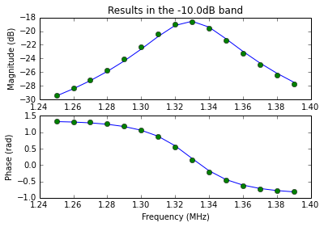

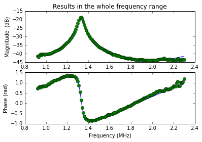

```python
if GraphOutput == 1:
    cT_band = cT_layer(caso1, lfinEFA, cttest1.ResWindow(LIMITE).freq())
    import pylab
    pylab.figure(1)
    pylab.subplot(211)
    pylab.title('Results in the -' + str(LIMITE)+'dB band')
    pylab.xlabel('Frequency (MHz)')
    pylab.ylabel('Magnitude (dB)')
    pylab.plot(cT_band.freq()/1e6, cT_band.mag(),cttest1.ResWindow(LIMITE).freq()/1e6,cttest1.ResWindow(LIMITE).mag(),'o')
    pylab.subplot(212)

    pylab.xlabel('Frequency (MHz)')
    pylab.ylabel('Phase (rad)')
    pylab.plot(cT_band.freq()/1e6, cT_band.phase(),cttest1.ResWindow(LIMITE).freq()/1e6,cttest1.ResWindow(LIMITE).phase(),'o')
    pylab.figure(2)
    pylab.subplot(211)
    pylab.title('Results in the whole frequency range')
    pylab.xlabel('Frequency (MHz)')
    pylab.ylabel('Magnitude  (dB)')
    pylab.plot(cT_fin.freq()/1e6, cT_fin.mag(),cttest1.freq()/1e6,cttest1.mag(),'o')
    pylab.subplot(212)

    pylab.xlabel('Frequency (MHz)')
    pylab.ylabel('Phase (rad)')
    pylab.plot(cT_fin.freq()/1e6, cT_fin.phase(),cttest1.freq()/1e6,cttest1.phase(),'o')
    pylab.show()
```